# Driving Anxiety Phase II

Irina Benedyk

2025-11-12

This study utilizes a driving simulator available at the **Transportation Research and Visualization Laboratory (TRAVL), University at Buffalo,** to investigate the behavior and physiological responses of young drivers (aged 18-25) in complex driving scenarios.

## Study Objectives

1. Examine how driving anxiety affects the behavioral of young drivers across different critical driving scenarios;
2. Quantify the impact of anxiety on drivers’ physiological and psychological states;
3. Explore whether affirmative feedback influences driver behavior, psychological state (level of anxiety), and self-reported safety perception during driving tasks.

## Key Takeaways

```
The pre-defined anxiety_group from Phase 1 are correlated with some aspects of gaze behavior. The Non-Anxious (N) group consistently had higher saccade_count and fixation_count across almost all scenarios, suggesting a more active visual scanning pattern than the Anxious (A) group.

The positive affirmation (between car and car_t2 scenarios) caused the two groups' gaze behavior to move in opposite directions.
  (1) The Anxious group's focused AIO attention increased (car_t2_aoi_dur_percent: +5.9%), while the Non-Anxious group's focus remained stable (car_t2_aoi_dur_percent: +0.4%).
  (2) After the affirmaiton the dwell time for Non-Anxious group decresed, while Anxious group demostrated increase.

The anxiety_group from Phase 1 are correlated with most of the self-reported cognitive state metrics such as feeling streesed, confused, or safe.
```

## Experiment Set Up

Four distinct experimental scenarios (two dynamic, two static) were developed within an Immersive Virtual Reality (IVE).

### Dynamic Scenario 1&2 - Sudden Vehicle at Intersection

This scenario simulated an unexpected vehicle intrusion at an urban intersection, modeled based on typical roadway configurations found in urban areas of New York State, and includes intersection with pedestrian crosswalks, signage, and stop lines. Participants navigated along a primary urban route encountering three intersections where participant has right of way. At the third intersection, a vehicle approached rapidly from a minor side street, deliberately entering the intersection without properly yielding at the stop sign. Participants were required to quickly perceive the intrusion and react accordingly.

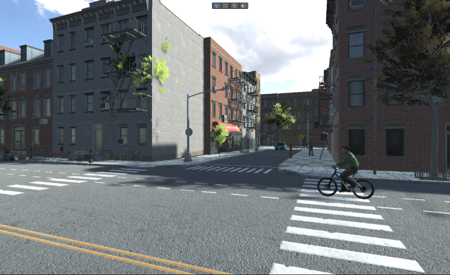

### Dynamic Scenario #3 - Unexpected Pedestrian Crossing

In this scenario, drivers transitioned from a rural roadway into an urbanized area, subsequently merging back into a rural environment. Upon passing a clearly marked unsignalized pedestrian crossing, participant encountered a pedestrian unexpectedly stepping onto the roadway which drivers will not have direct sight distance to until they are very close.

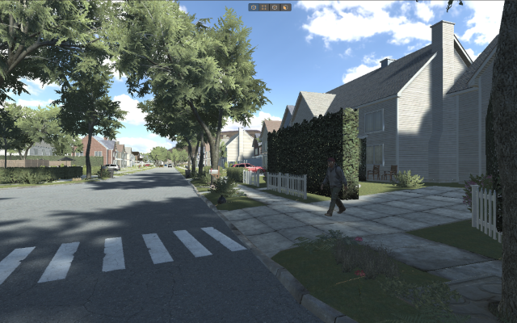

### Static Scenario #4 - Garbage Truck Obstructing

This static scenario simulated a rural residential environment involving restricted forward visibility caused by stationary garbage truck. The truck model and positioning were chosen based on common real-world garbage collection operations, verified through pilot testing to ensure visibility obstruction.

[figure not shown]

### Static Scenario #5- Utility Construction Zone

This static scenario involved navigating through a rural residential environment partially blocked due to ongoing construction work. The scene was carefully designed according to standard roadway construction configurations outlined in the Manual on Uniform Traffic Control Devices (MUTCD). The setup featured a manhole surrounded by clearly marked construction barriers and signage.

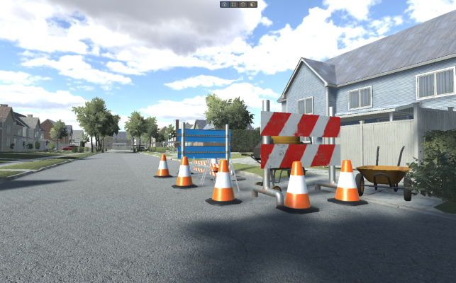

## Approach to scenario randomization

Scenarios were presented in a partially randomized order to control potential sequence effects and enhance experimental validity. Each scenario lasted approximately 3 minutes. At the beginning of each session, participants first completed two dynamic scenarios, either the Sudden Vehicle Intrusion or the Unexpected Pedestrian Crossing scenario was presented first, selected randomly to minimize order effects. This was followed by one of the two static scenarios, either the Utility Construction Zone or the Garbage Truck Obstruction, also selected in a randomized order for each participant to balance potential sequence biases.

After the initial exposure to two dynamic and one static scenario, participants received standardized **affirmative feedback** emphasizing positive aspects of their performance, intended to reinforce confidence before the subsequent second run of the Sudden Vehicle Intrusion (dynamic) scenario.

Finally, all participants completed a second static scenario (that was not presented before), allowing for within-subject comparisons to assess the impacts of positive affirmative on driving behaviors and perceived driving anxiety.

Importantly, participants were not informed that they would repeat the Sudden Vehicle Intrusion scenario, ensuring that their responses during the second exposure reflected genuine reactions without anticipation of bias.

## Major observations on the impact of the positive affirmation

A comparison of visual behavior before and after positive affirmation in Car scenario for both Anxious (A) and Non-Anxious (N) groups.

### General Scanning (Saccades & Fixations):

[output not shown]

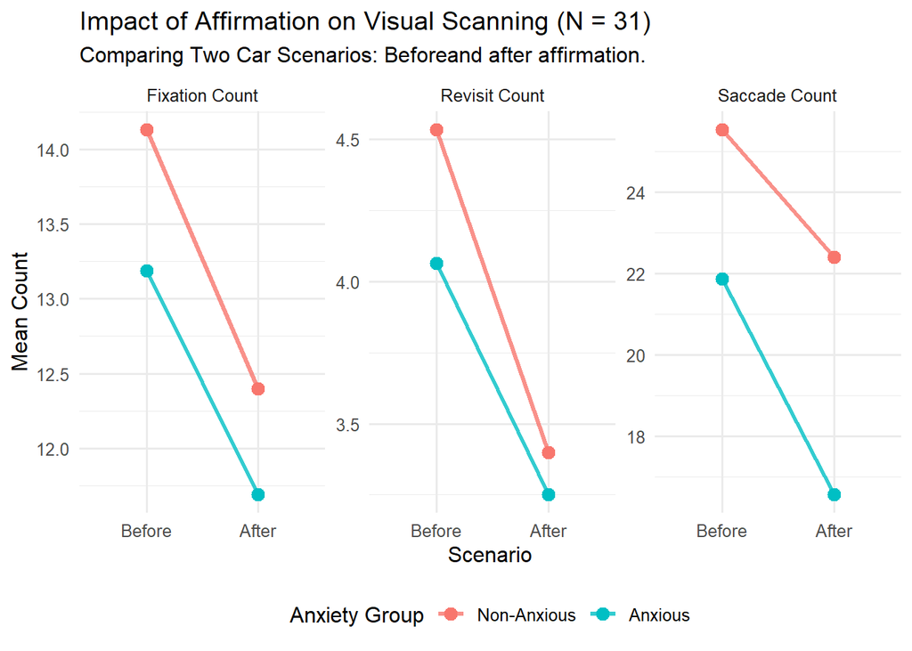

### Gaze Focus (Duration & Dwell Time):

[output not shown]

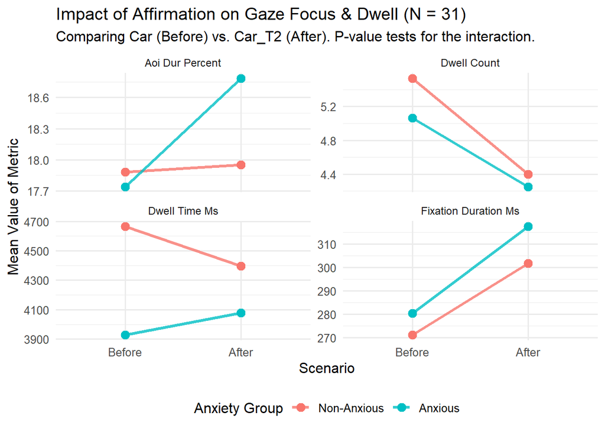

### Statistical Significance:

```
While these results demostrate some important trends, the t-test on the difference-in-differences (comparing the change in A-group vs. the change in N-group) did not show a statistically significant interaction for all metric (all p-values > 0.05) but one.

This "lack of significance" does not mean there was no effect. It means we cannot statistically prove that the affirmation's effect was different for the two groups.
```

## Major observations based on the post-experiment survey

Comparing the 16 Anxious (A) participants and 15 Non-Anxious (N) participants.

### Scenario-Specific Anxiety (1-9 Scale)

#### Major observations based on the statistical output from your code for the ‘I Was Stressed’

[output not shown]

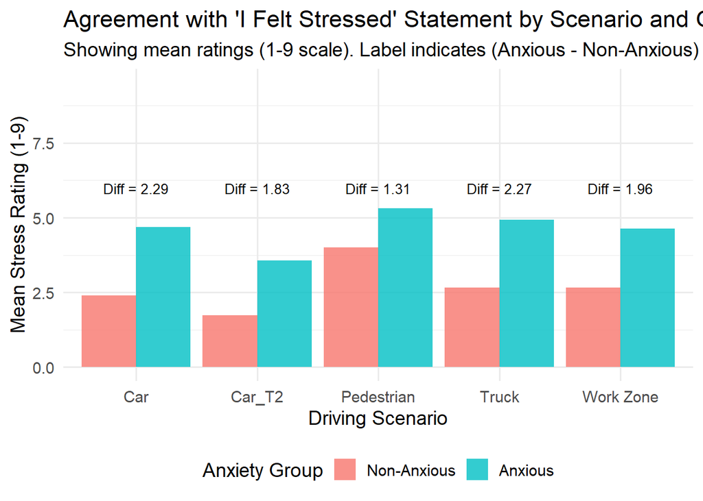

T-Test P-Values: ‘I Felt Stressed’ (Anxious vs. Non-Anxious)

| Scenario | P-Value |
| --- | --- |
| Car | 0.004 |
| Car_T2 | 0.006 |
| Pedestrian | 0.145 |
| Truck | 0.003 |
| Work Zone | 0.008 |

#### Major observations based on the statistical output from your code for the ‘I Was Confused’

[output not shown]

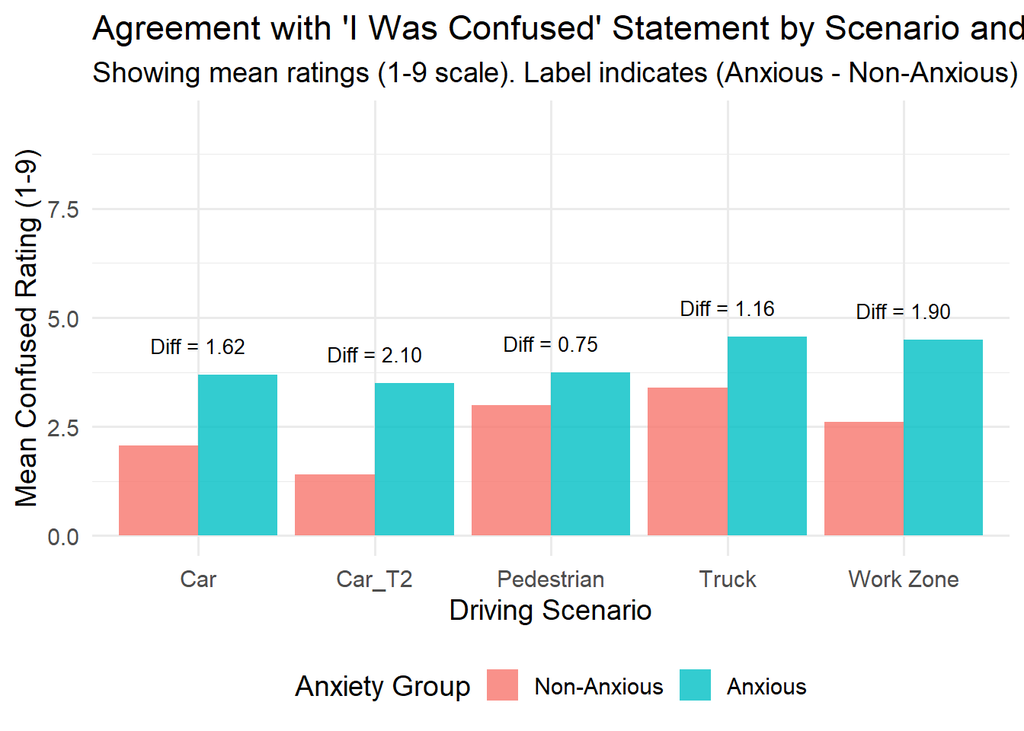

T-Test P-Values: ‘I Was Confused’ (Anxious vs. Non-Anxious)

| Scenario | P-Value |
| --- | --- |
| Car | 0.009 |
| Car_T2 | 0.000 |
| Pedestrian | 0.288 |
| Truck | 0.107 |
| Work Zone | 0.015 |

#### Major observations based on the statistical analysis of the ‘I Felt Safe’

(Note: For this question, a higher score (1-9) means “Completely agree” / felt more safe.)

```
This is the most conclusive finding across all three survey questions. The difference between the two groups is statistically significant (p < 0.01) for every single scenario. The Non-Anxious group's mean safety rating was consistently high (between 7.27 and 8.60), while the Anxious group's ratings were substantially lower (between 5.38 and 6.69).

Unlike the "confusion" metrics, the positive affirmation had a positive effect on safety ratings for both groups. The Anxious group's safety rating rose from 6.31 to 6.69, and the Non-Anxious group's rating also rose from 8.13 to 8.60. Both groups felt safest in the Car_T2 scenario.

The "Safest" Scenario for the Anxious Group Was Still Worse Than the "Least Safe" for the Non-Anxious Group. To put the gap in perspective, the highest mean safety rating for the Anxious group (6.69 in Car_T2) was still significantly lower than the lowest mean safety rating for the Non-Anxious group (7.27 in Pedestrian).
```

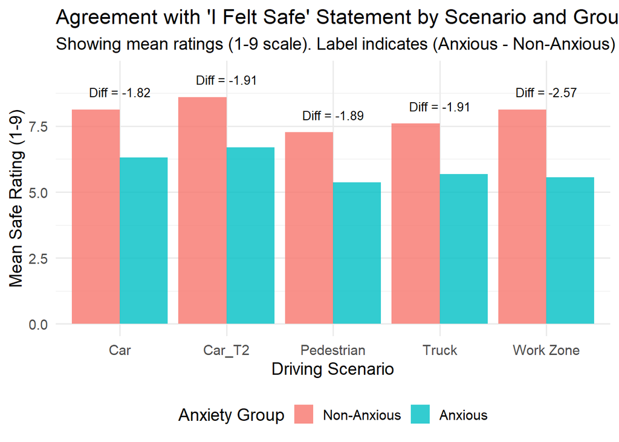

T-Test P-Values: ‘I Felt Safe’ (Anxious vs. Non-Anxious)

| Scenario | P-Value |
| --- | --- |
| Car | 0.000 |
| Car_T2 | 0.000 |
| Pedestrian | 0.002 |
| Truck | 0.006 |
| Work Zone | 0.000 |

### Post-Experiment Perceptions: Simulation Sickness

[output not shown]

Mean Simulator Sickness (SSQ) Score

| Anxiety Group | Mean SSQ Score |
| --- | --- |
| Non-Anxious | 3.05 |
| Anxious | 3.17 |

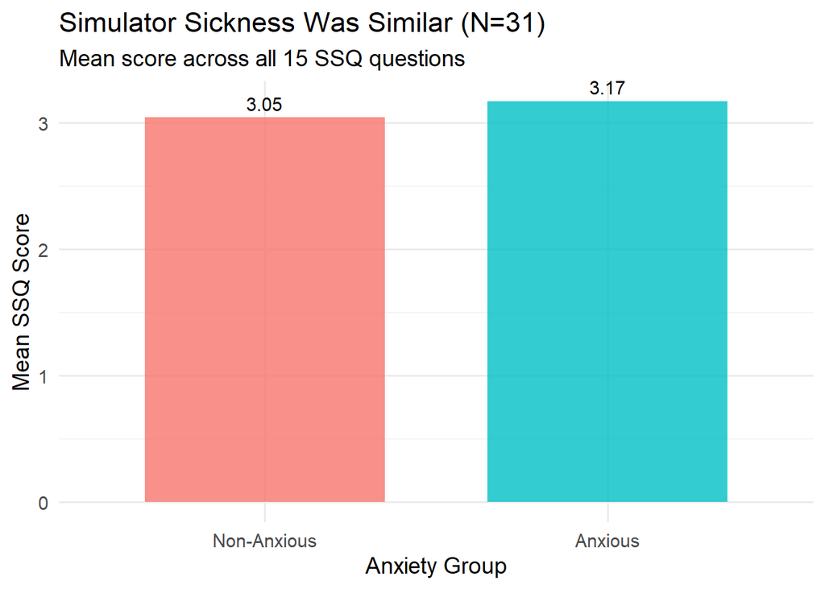

### Post-Experiment Perceptions: Simulator Perception

```
Contrary to what might be expected, the Anxious group rated the "Overall realism of the simulation" and "Realism of visual events" higher than the Non-Anxious group.

The Non-Anxious group gave higher ratings for percieved steering realism (5.53 vs 5.06) and percieved steering vehicle response (5.20 vs 4.56), suggesting they felt the simulator's controls were more realistic or comfortable than the Anxious group did.
```

```
## [1] "~~~ Mean Simulator Perception Ratings (1-9 Scale) ~~~"
```

Mean Simulator Perception Ratings (1-9 Scale)

| question_label | Non-Anxious | Anxious |
| --- | --- | --- |
| Realism of Sim | 4.07 | 5.00 |
| Realism of Events | 4.13 | 5.00 |
| Steering Control | 5.53 | 5.06 |
| Vehicle Response | 5.20 | 4.56 |

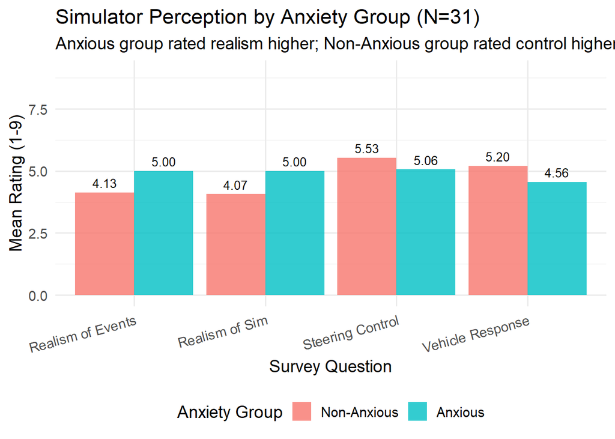